# Final_Project (1)

## Final Project

### Rules of Engagement:

This is an **honor system assignment**: You may consult your professor, your lab instructor, the textbook, and material on the Internet at any time. You may not consult, collaborate, or seek assistance from any other human besides your professor and lab instructor. Your attribution statement, at the top of your R-code file, should reflect these constraints. You may not share your results or work in progress with any other human besides your professor or lab instructor. Note that your data file is unique to you: The results that other students in IST387 obtain will be different from yours.

### Project Goal:

The goal of this term project is for you to use all of the skills you have developed in the labs/homework to make sense of a novel dataset, to perform some essential analyses on the dataset, and to explain/document what you have done. The dataset contains real-life hotel stay data, with each row representing a hotel booking.

### The Data File:

Here are the variables you will find in your data file:

• **IsCanceled**: Categorical Value indicating if the booking was canceled (1) or not (0)  
• **LeadTime**: Integer, Number of days that elapsed between the entering date of the booking into and the arrival date  
• **StaysInWeekendNights**: Integer, Number of weekend nights (Saturday or Sunday) the guest stayed or booked to stay at the hotel  
• **StaysInWeekNights**: Integer, Number of week nights (Monday to Friday) the guest stayed or booked to stay at the hotel  
• **Adults**: Integer, Number of adults  
• **Children**: Integer, Number of children  
• **Babies**: Integer, Number of babies  
• **Meal**: Categorical, Type of meal booked. Categories are presented in standard hospitality meal packages:  
Undefined/SC – no meal package;  
BB – Bed & Breakfast;  
HB – Half board (breakfast and one other meal – usually dinner);  
FB – Full board (breakfast, lunch and dinner)  
• **Country**: Categorical, Country of origin. Categories are represented in the ISO 3155–3:2013 format  
• **MarketSegment**: Categorical, Market segment designation. In categories, the term “TA” means “Travel Agents” and “TO” means “Tour Operators”  
• **IsRepeatedGuest**: Categorical, Value indicating if the booking name was from a repeated guest (1) or not (0)  
• **PreviousCancellations**: Integer, Number of previous bookings that were cancelled by the customer prior to the current booking  
• **PreviousBookingsNotCanceled**: Integer, Number of previous bookings not cancelled by the customer prior to the current booking  
• **ReservedRoomType**: Categorical, Code of room type reserved. Code is presented instead of designation for anonymity reasons  
• **AssignedRoomType**: Categorical, Code for the type of room assigned to the booking. Sometimes the assigned room type differs from the reserved room type due to hotel operation reasons (e.g. overbooking) or by customer request. Code is presented instead of designation for anonymity reasons  
• **BookingChanges**: Integer, Number of changes/amendments made to the booking from the moment the booking was entered on the PMS until the moment of check-in or cancellation  
• **DepositType**: Categorical, Indication on if the customer made a deposit to guarantee the booking. This variable can assume three categories:  
No Deposit – no deposit was made.  
Non Refund – a deposit was made in the value of the total stay cost.  
Refundable – a deposit was made with a value under the total cost of stay.  
• **CustomerType**: Categorical, Type of booking, assuming one of four categories:  
Contract - when the booking has an allotment or other type of contract associated to it;  
Group – when the booking is associated to a group;  
Transient – when the booking is not part of a group or contract, and is not associated to other transient booking;  
Transient-party – when the booking is transient, but is associated to at least other transient booking  
• **RequiredCardParkingSpaces**: Integer, Number of car parking spaces required by the customer  
• **TotalOfSpecialRequests**: Integer, Number of special requests made by the customer (e.g. twin bed or high floor)

### Ten Steps to Complete the Project:

1. Use **read_csv()** to read your CSV file (https://ist387.s3.us-east-2.amazonaws.com/data/Resort.csv) into a dataframe called **bookings**. Describe the variables in the dataframe using descriptive statistics – add a brief comment to explain what you see. How many observations and variables does the dataframe have? - Add a comment.

```r
library(tidyverse)

bookings <- read_csv("https://ist387.s3.us-east-2.amazonaws.com/data/Resort.csv")
str(bookings) #7 of the 20 columns (variables) are character columns, so there are no descriptive stats available
summary(bookings) #take `LeadTime` for instance: it has a min of 0, max of 737, median of 57, and mean of 92.68
```

```
tibble [40,060 × 20] (S3: spec_tbl_df/tbl_df/tbl/data.frame)
 $ IsCanceled                 : num [1:40060] 0 0 0 0 0 0 0 0 1 1 ...
 $ LeadTime                   : num [1:40060] 342 737 7 13 14 14 0 9 85 75 ...
 $ StaysInWeekendNights       : num [1:40060] 0 0 0 0 0 0 0 0 0 0 ...
 $ StaysInWeekNights          : num [1:40060] 0 0 1 1 2 2 2 2 3 3 ...
 $ Adults                     : num [1:40060] 2 2 1 1 2 2 2 2 2 2 ...
 $ Children                   : num [1:40060] 0 0 0 0 0 0 0 0 0 0 ...
 $ Babies                     : num [1:40060] 0 0 0 0 0 0 0 0 0 0 ...
 $ Meal                       : chr [1:40060] "BB" "BB" "BB" "BB" ...
 $ Country                    : chr [1:40060] "PRT" "PRT" "GBR" "GBR" ...
 $ MarketSegment              : chr [1:40060] "Direct" "Direct" "Direct" "Corporate" ...
 $ IsRepeatedGuest            : num [1:40060] 0 0 0 0 0 0 0 0 0 0 ...
 $ PreviousCancellations      : num [1:40060] 0 0 0 0 0 0 0 0 0 0 ...
 $ PreviousBookingsNotCanceled: num [1:40060] 0 0 0 0 0 0 0 0 0 0 ...
 $ ReservedRoomType           : chr [1:40060] "C" "C" "A" "A" ...
 $ AssignedRoomType           : chr [1:40060] "C" "C" "C" "A" ...
 $ BookingChanges             : num [1:40060] 3 4 0 0 0 0 0 0 0 0 ...
 $ DepositType                : chr [1:40060] "No Deposit" "No Deposit" "No Deposit" "No Deposit" ...
 $ CustomerType               : chr [1:40060] "Transient" "Transient" "Transient" "Transient" ...
 $ RequiredCarParkingSpaces   : num [1:40060] 0 0 0 0 0 0 0 0 0 0 ...
 $ TotalOfSpecialRequests     : num [1:40060] 0 0 0 0 1 1 0 1 1 0 ...
 - attr(*, "spec")=
  .. cols(
  ..   IsCanceled = col_double(),
  ..   LeadTime = col_double(),
  ..   StaysInWeekendNights = col_double(),
  ..   StaysInWeekNights = col_double(),
  ..   Adults = col_double(),
  ..   Children = col_double(),
  ..   Babies = col_double(),
  ..   Meal = col_character(),
  ..   Country = col_character(),
  ..   MarketSegment = col_character(),
  ..   IsRepeatedGuest = col_double(),
  ..   PreviousCancellations = col_double(),
  ..   PreviousBookingsNotCanceled = col_double(),
  ..   ReservedRoomType = col_character(),
  ..   AssignedRoomType = col_character(),
  ..   BookingChanges = col_double(),
  ..   DepositType = col_character(),
  ..   CustomerType = col_character(),
  ..   RequiredCarParkingSpaces = col_double(),
  ..   TotalOfSpecialRequests = col_double()
  .. )
```

```
   IsCanceled        LeadTime      StaysInWeekendNights StaysInWeekNights
 Min.   :0.0000   Min.   :  0.00   Min.   : 0.00        Min.   : 0.000
 1st Qu.:0.0000   1st Qu.: 10.00   1st Qu.: 0.00        1st Qu.: 1.000
 Median :0.0000   Median : 57.00   Median : 1.00        Median : 3.000
 Mean   :0.2776   Mean   : 92.68   Mean   : 1.19        Mean   : 3.129
 3rd Qu.:1.0000   3rd Qu.:155.00   3rd Qu.: 2.00        3rd Qu.: 5.000
 Max.   :1.0000   Max.   :737.00   Max.   :19.00        Max.   :50.000
     Adults          Children           Babies           Meal
 Min.   : 0.000   Min.   : 0.0000   Min.   :0.0000   Length:40060
 1st Qu.: 2.000   1st Qu.: 0.0000   1st Qu.:0.0000   Class :character
 Median : 2.000   Median : 0.0000   Median :0.0000   Mode  :character
 Mean   : 1.867   Mean   : 0.1287   Mean   :0.0139
 3rd Qu.: 2.000   3rd Qu.: 0.0000   3rd Qu.:0.0000
 Max.   :55.000   Max.   :10.0000   Max.   :2.0000
   Country          MarketSegment      IsRepeatedGuest   PreviousCancellations
 Length:40060       Length:40060       Min.   :0.00000   Min.   : 0.0000
 Class :character   Class :character   1st Qu.:0.00000   1st Qu.: 0.0000
 Mode  :character   Mode  :character   Median :0.00000   Median : 0.0000
                                       Mean   :0.04438   Mean   : 0.1017
                                       3rd Qu.:0.00000   3rd Qu.: 0.0000
                                       Max.   :1.00000   Max.   :26.0000
 PreviousBookingsNotCanceled ReservedRoomType   AssignedRoomType
 Min.   : 0.0000             Length:40060       Length:40060
 1st Qu.: 0.0000             Class :character   Class :character
 Median : 0.0000             Mode  :character   Mode  :character
 Mean   : 0.1465
 3rd Qu.: 0.0000
 Max.   :30.0000
 BookingChanges   DepositType        CustomerType
 Min.   : 0.000   Length:40060       Length:40060
 1st Qu.: 0.000   Class :character   Class :character
 Median : 0.000   Mode  :character   Mode  :character
 Mean   : 0.288
 3rd Qu.: 0.000
 Max.   :17.000
 RequiredCarParkingSpaces TotalOfSpecialRequests
 Min.   :0.0000           Min.   :0.0000
 1st Qu.:0.0000           1st Qu.:0.0000
 Median :0.0000           Median :0.0000
 Mean   :0.1381           Mean   :0.6198
 3rd Qu.:0.0000           3rd Qu.:1.0000
 Max.   :8.0000           Max.   :5.0000
```

1. Check the numerical variables for missing values using the **is.na()** technique we used in HW 8:

```r
any(is.na(bookings)) #scan whole tibble for na
sum(is.na(bookings)) #count total na in tibble to be sure

table(is.na(bookings$IsCanceled)) #spot check
table(is.na(bookings$LeadTime)) #spot check
table(is.na(bookings$StaysInWeekendNights)) #spot check
table(is.na(bookings$StaysInWeekNights)) #spot check
```

FALSE

0

```
FALSE
40060
```

```
FALSE
40060
```

```
FALSE
40060
```

```
FALSE
40060
```

1. Create histograms for any 3 numeric variables. Write a sentence about each histogram, describing its distribution. Generate tables (using the **table()** function) for any 3 categorical response variables (e.g., **Meal**), and write a sentence for each, describing what you see. Add a comment listing the country with the largest number of bookings and show the code you used to identify it:

**null device:** 1

```
       BB        FB        HB        SC Undefined
    30005       754      8046        86      1169
```

```
  PRT   GBR   ESP   IRL   FRA   DEU    CN   NLD   USA  NULL   ITA   BEL   CHE
17630  6814  3957  2166  1611  1203   710   514   479   464   459   448   435
  BRA   POL   SWE   AUT   RUS   ROU   FIN   CHN   NOR   AUS   LUX   MAR   DNK
  430   333   304   210   189   177   151   134   123    87    80    75    65
  ARG   HUN   LTU   IND   EST   LVA   ISR   CZE   AGO   TUR   UKR   ZAF   CHL
   57    47    46    37    33    33    28    27    24    23    23    18    17
  COL   PHL   NZL   GIB   DZA   SVK   TWN   ARE   GEO   HRV   OMN   SVN   GRC
   16    16    14    13    12    12    12    11    11    11    11    11    10
  MYS   NGA   JPN   KOR   PRI   CYP   URY   BLR   SRB   ISL   LBN   MDV   MEX
   10    10     9     9     9     8     8     7     7     6     6     6     6
  MOZ   THA   AND   BGR   CPV   IDN   IRN   JAM   KAZ   CUB   HKG   PAK   SGP
    6     6     5     5     5     5     5     5     5     4     4     4     4
  SUR   ALB   AZE   CAF   DOM   JEY   KWT   VEN   ARM   CIV   CMR   CRI   ECU
    4     3     3     3     3     3     3     3     2     2     2     2     2
  JOR   MLT   MWI   VNM   ZWE   BDI   BHR   BHS   BIH   BWA   COM   CYM   DJI
    2     2     2     2     2     1     1     1     1     1     1     1     1
  EGY   FJI   GGY   LKA   MAC   MDG   MKD   MUS   NPL   PER   PLW   QAT   SAU
    1     1     1     1     1     1     1     1     1     1     1     1     1
  SEN   SMR   SYC   SYR   TGO   TUN   UGA   UZB   ZMB
    1     1     1     1     1     1     1     1     1
```

```
Complementary     Corporate        Direct        Groups Offline TA/TO
          201          2309          6513          5836          7472
    Online TA
        17729
```

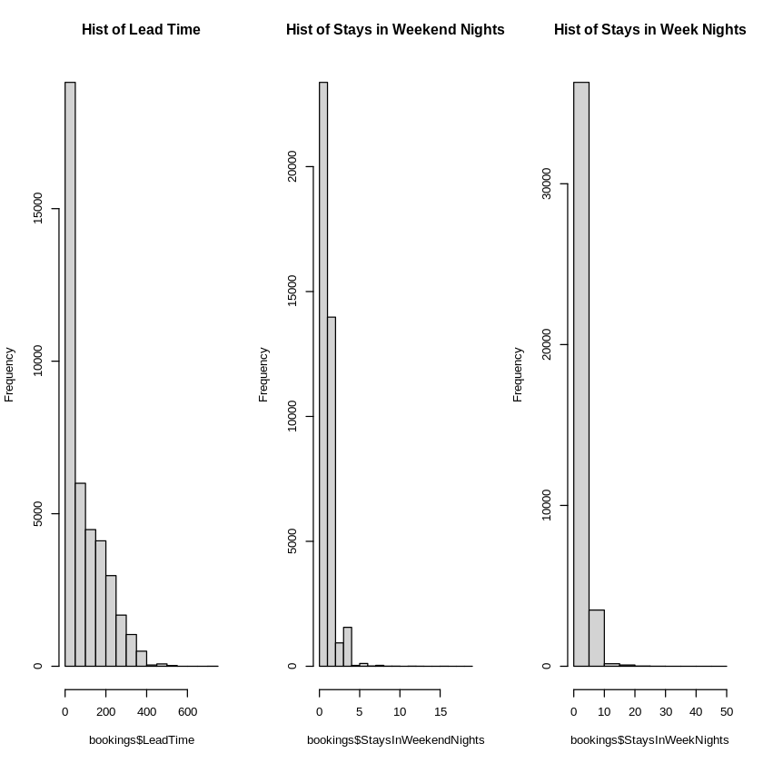

```r
par(mfrow = c(1,3))
hist(bookings$LeadTime,main="Hist of Lead Time") #distribution is skewed to the right, in a decreasingly exponential pattern, indicating that the great majority of bookings were made with little time before arrival
hist(bookings$StaysInWeekendNights,main="Hist of Stays in Weekend Nights") #also exponentially decreasing, as well as skewed to the right, meaning that most guests stayed for one weekend only (either one or two days)
hist(bookings$StaysInWeekNights,main="Hist of Stays in Week Nights") #again, exponentially decreasing, since shorter stays are more popular with guests
dev.off()

table(bookings$Meal) #Bed and Breakfast is by far the most common, whereas no meal package is the least common
sort(table(bookings$Country),decreasing=TRUE) #Portugal is the most common country of origin, followed by Great Britain and Spain
table(bookings$MarketSegment) #Online Travel Agents is the most common way guests made their booking, while complementary bookings are the least common
```

1. Create three boxplots for **IsCanceled**, using each of these grouping variables: **LeadTime**, **StaysInWeekNights**, **PreviousCancellations**. Add a comment explaining each boxplot:

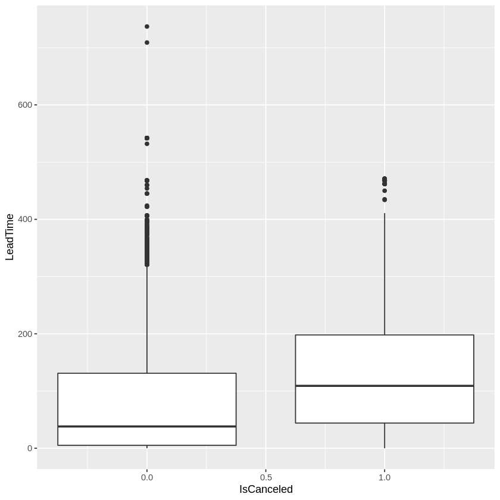

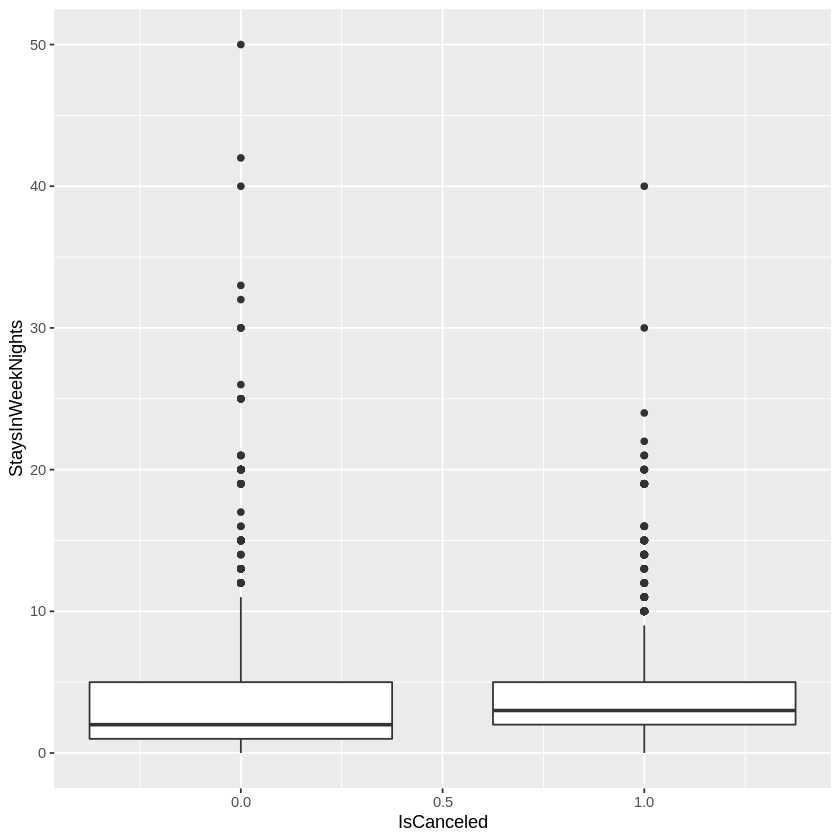

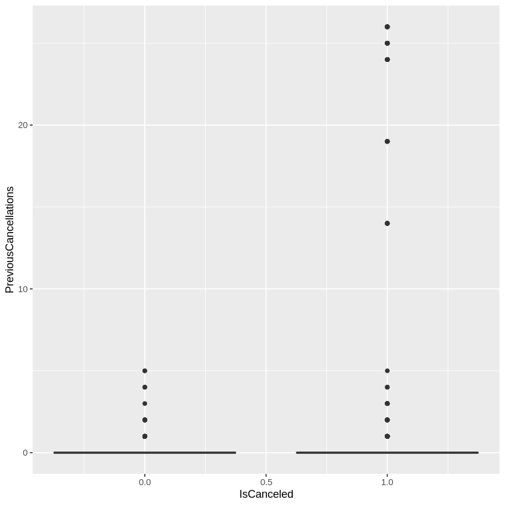

```r
bookings %>%
  ggplot()+
  geom_boxplot(aes(IsCanceled,LeadTime,group=IsCanceled))
# the median lead time for cancelled bookings is higher than that of the uncancelled bookings; however, Uncancelled bookings have many more outliers to the high end of lead time (longer)

bookings %>%
  ggplot()+
  geom_boxplot(aes(IsCanceled,StaysInWeekNights,group=IsCanceled))
# these boxplots are fairly comparable, with medians (and the quartiles) generally in the same range - THis means that there is hardly a correlation between cancelled bookings and number of week nights the guest stayed or booked for [if I had to differentiate, the median for cancelled bookings is slightly higher than uncancelled]

bookings %>%
  ggplot()+
  geom_boxplot(aes(IsCanceled,PreviousCancellations,group=IsCanceled))
#there is not much data here, so the plots are somewhat underwhelming - that being said, cancelled bookings tend to have cancelled other bookings in the past, so it can be a useful indicator
```

1. Currently, the data is at the individual booking level. Using the **aggregate()** function from HW 7 and the midterm, create a new dataframe called **country** based on the **Country** and **IsCanceled** variables, to show the total number of cancellations for each country. Possible names for the resulting two columns in **country** are **name** and **numCanceled**. Using the subsetting technique we showed in HW 7, display the country with the highest number of cancellations:

```r
bookings %>%
  select(Country, IsCanceled) %>%
  group_by(Country) %>%
  summarise(sumcancel = sum(IsCanceled)) -> cancel.count

cancel.count[which.max(cancel.count$sumcancel),]
```

A tibble: 1 × 2

| Country <chr> | sumcancel <dbl> |
| --- | --- |
| PRT | 7438 |

1. Create a color gradient world map where the color of each country indicates its total number of cancellations. Assuming your dataframe is called **country**, here is code to do this:

```r
#install.packages("rworldmap")
#library(rworldmap)
#sPDF <- joinCountryData2Map( country, joinCode = "ISO3", nameJoinColumn = "name")
#map<-mapCountryData(sPDF, nameColumnToPlot='numCanceled', catMethod="logFixedWidth")
```